# Project2_Mai_Todd_Carlos

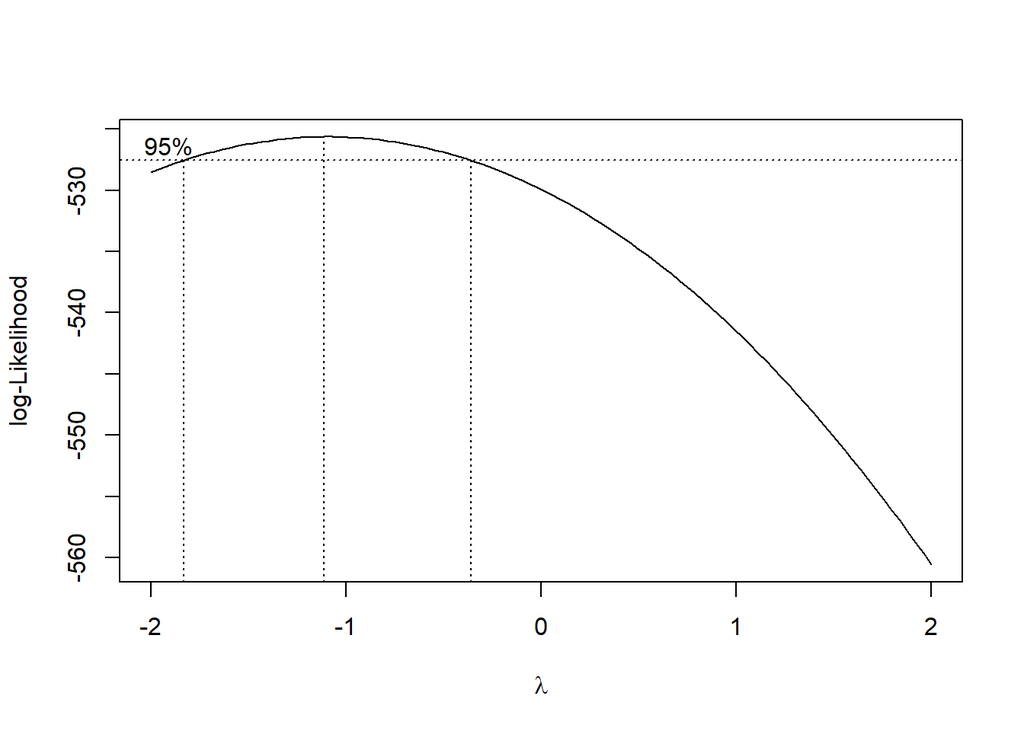

```r
bc <- boxcox(lm(data$age ~ 1))  # Dummy regression for Box-Cox
```

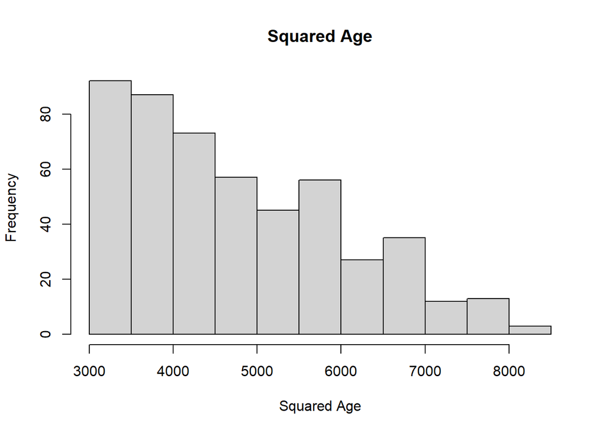

```r
lambda <- bc$x[which.max(bc$y)]
data$boxcox_age <- (data$age^lambda - 1) / lambda

# Histograms to check the distribution after transformation
hist(data$squared_age, main = "Squared Age", xlab = "Squared Age")
```

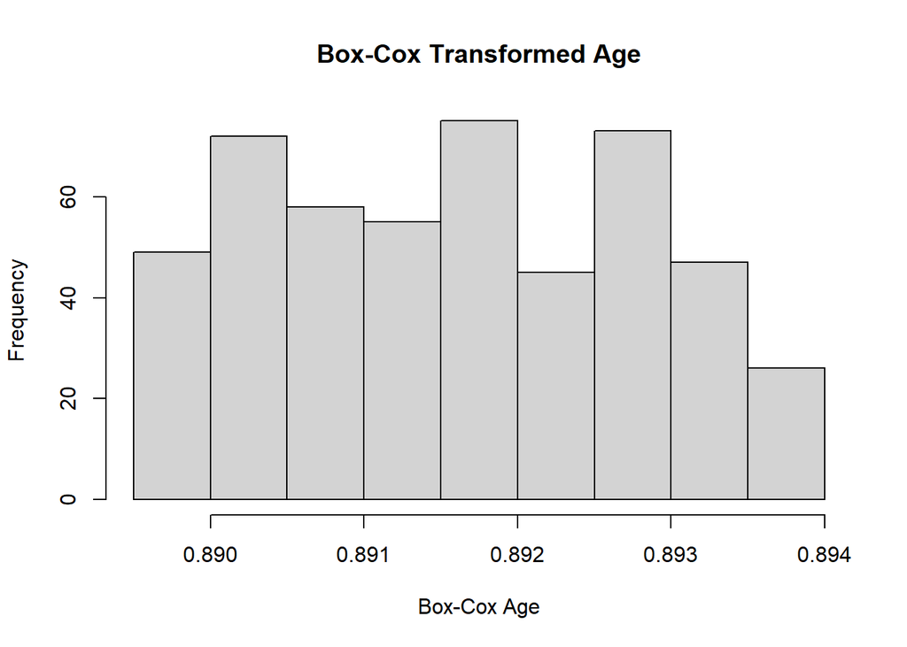

```r
hist(data$boxcox_age, main = "Box-Cox Transformed Age", xlab = "Box-Cox Age")
```

# The Box-Cox transformation looks the best but still far from perfect.

# As interpretation of the variables is the goal, versus prediction, I’m not sure Box-Cox is the best choice. And, since normality isn’t a concern, perhaps we use no transformation. Let’s try a logistic regression using glm() and view our results.

```r
datanew <- data[-c(19:22)]

# Building Logistic Regression Model
glm_model <- glm(fracture ~ ., data = datanew, family = binomial())
# Summary of the Model for Interpretation
summary(glm_model)
```

```
##
## Call:
## glm(formula = fracture ~ ., family = binomial(), data = datanew)
##
## Coefficients:
##                   Estimate Std. Error z value Pr(>|z|)
## (Intercept)     -4.063e+02  1.124e+06   0.000    1.000
## sub_id           1.824e+00  1.734e+02   0.011    0.992
## site_id         -8.271e-01  1.333e+04   0.000    1.000
## phy_id          -3.520e-02  1.520e+02   0.000    1.000
## priorfracYes    -6.839e+00  2.387e+04   0.000    1.000
## age             -8.582e-01  3.673e+03   0.000    1.000
## weight           1.225e+00  6.956e+03   0.000    1.000
## height          -1.754e+00  6.596e+03   0.000    1.000
## bmi             -1.906e+00  1.803e+04   0.000    1.000
## premenoYes       4.477e+00  1.001e+04   0.000    1.000
## momfracYes      -1.534e+01  2.030e+04  -0.001    0.999
## armassistYes    -9.857e+00  2.132e+04   0.000    1.000
## smokeYes        -2.026e+01  3.869e+04  -0.001    1.000
## rateriskSame     2.128e+01  1.806e+04   0.001    0.999
## rateriskGreater  2.641e+01  3.785e+04   0.001    0.999
## fracscore        6.765e+00  1.098e+04   0.001    1.000
## bonemedYes      -1.988e+01  3.068e+04  -0.001    0.999
## bonemed_fuYes    2.815e+01  1.957e+04   0.001    0.999
## bonetreatYes    -4.151e+00  4.000e+04   0.000    1.000
##
## (Dispersion parameter for binomial family taken to be 1)
##
##     Null deviance: 5.6234e+02  on 499  degrees of freedom
## Residual deviance: 2.3664e-07  on 481  degrees of freedom
## AIC: 38
##
## Number of Fisher Scoring iterations: 25
```

```r
View(datanew)
```

# These results show a clear separation of variables. The SE values are Huge

```r
# Check for imbalance in response variable
table(data$fracture)
```

```
##
##  No Yes
## 375 125
```

```r
# Standard Logistic Regression Model
glm_fit <- glm(fracture ~ ., data = datanew, family = binomial())
# Check the summary of the model
summary(glm_fit)
```

```
##
## Call:
## glm(formula = fracture ~ ., family = binomial(), data = datanew)
##
## Coefficients:
##                   Estimate Std. Error z value Pr(>|z|)
## (Intercept)     -4.063e+02  1.124e+06   0.000    1.000
## sub_id           1.824e+00  1.734e+02   0.011    0.992
## site_id         -8.271e-01  1.333e+04   0.000    1.000
## phy_id          -3.520e-02  1.520e+02   0.000    1.000
## priorfracYes    -6.839e+00  2.387e+04   0.000    1.000
## age             -8.582e-01  3.673e+03   0.000    1.000
## weight           1.225e+00  6.956e+03   0.000    1.000
## height          -1.754e+00  6.596e+03   0.000    1.000
## bmi             -1.906e+00  1.803e+04   0.000    1.000
## premenoYes       4.477e+00  1.001e+04   0.000    1.000
## momfracYes      -1.534e+01  2.030e+04  -0.001    0.999
## armassistYes    -9.857e+00  2.132e+04   0.000    1.000
## smokeYes        -2.026e+01  3.869e+04  -0.001    1.000
## rateriskSame     2.128e+01  1.806e+04   0.001    0.999
## rateriskGreater  2.641e+01  3.785e+04   0.001    0.999
## fracscore        6.765e+00  1.098e+04   0.001    1.000
## bonemedYes      -1.988e+01  3.068e+04  -0.001    0.999
## bonemed_fuYes    2.815e+01  1.957e+04   0.001    0.999
## bonetreatYes    -4.151e+00  4.000e+04   0.000    1.000
##
## (Dispersion parameter for binomial family taken to be 1)
##
##     Null deviance: 5.6234e+02  on 499  degrees of freedom
## Residual deviance: 2.3664e-07  on 481  degrees of freedom
## AIC: 38
##
## Number of Fisher Scoring iterations: 25
```

# Let’s try another route. Let’s perform a Lasso regression to help with feature selection.

```r
library(glmnet)
glow_bonemed_new <- data.frame(glow_bonemed_new)
#str(glow_bone_new)

# Convert categorical variables to dummy variables
data_matrix <- model.matrix(~ . - 1, data = glow_bonemed_new)

# Response variable as binary (0/1)
response <- as.numeric(datanew$fracture) - 1

# Fit the Lasso model using cross-validation
cv_fit <- cv.glmnet(data_matrix, response, family = "binomial", alpha = 1)

# Optimal lambda
opt_lambda <- cv_fit$lambda.min
opt_lambda
```

```
## [1] 0.0006430101
```

```r
# Re-fit the Lasso model with the selected lambda
lasso_fit <- glmnet(data_matrix, response, family = "binomial", alpha = 1, lambda = opt_lambda)

# View the coefficients
coef(lasso_fit)
```

```
## 18 x 1 sparse Matrix of class "dgCMatrix"
##                        s0
## (Intercept)     -7.898191
## priorfracNo      .
## priorfracYes     .
## age              .
## weight           .
## height           .
## bmi              .
## premenoYes       .
## momfracYes       .
## armassistYes     .
## smokeYes         .
## rateriskSame     .
## rateriskGreater  .
## fracscore        .
## fractureYes     14.697027
## bonemedYes       .
## bonemed_fuYes    .
## bonetreatYes     .
```

# These seem like unrealistic results. With such large values in the intercept and FractureYes, this would drastically increase the log odds of the response variable. The lambda value is virtually a Ridge method. Let’s dig into the data. Model Diagnostics, Data Balance, Model Comparison and Cross-Validation.

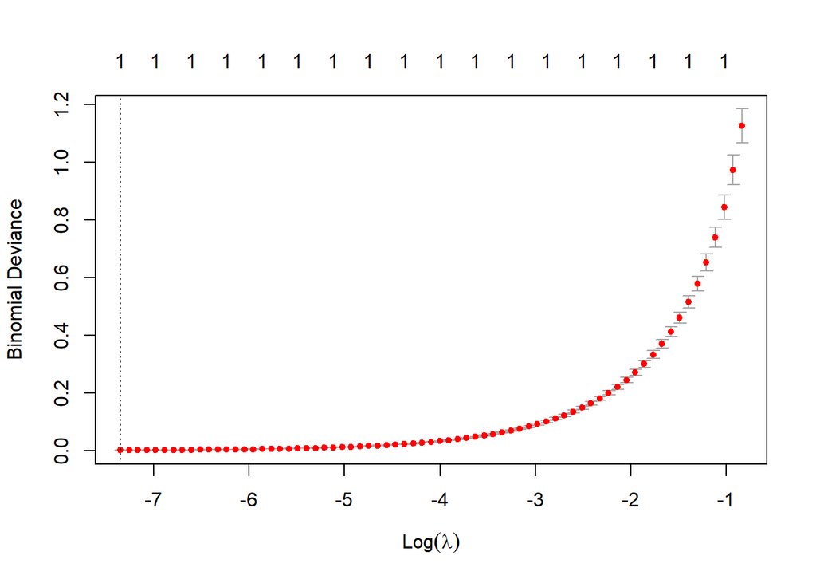

```r
# Cross-validation to find optimal lambda
cv_fit <- cv.glmnet(data_matrix, response, family = "binomial", alpha = 1)

# Plot the cross-validation result
plot(cv_fit)
```

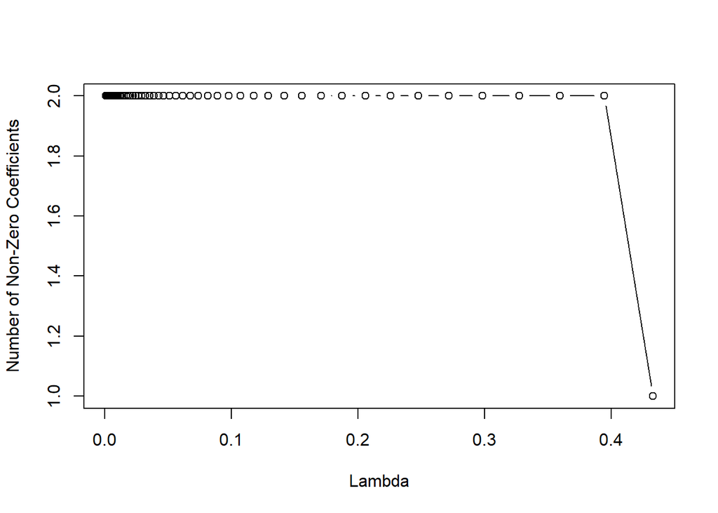

```r
# Look at the number of non-zero coefficients across different lambda values
coef_count <- sapply(cv_fit$lambda, function(l) {
  sum(coef(cv_fit, s = l) != 0)
})

# Plot number of non-zero coefficients against lambda values
plot(cv_fit$lambda, coef_count, type = "b", xlab = "Lambda", ylab = "Number of Non-Zero Coefficients")
```

# These results are puzzling. Perhaps a less aggressive approach, the Ridge regression.

```r
# Fit a Ridge regression model using glmnet
ridge_fit <- cv.glmnet(data_matrix, response, family = "binomial", alpha = 0)  # alpha = 0 for Ridge

# Optimal lambda
optimal_lambda_ridge <- ridge_fit$lambda.min
optimal_lambda_ridge
```

```
## [1] 0.04330127
```

```r
# Summary of the Ridge model with optimal lambda
coef(ridge_fit, s = optimal_lambda_ridge)
```

```
## 18 x 1 sparse Matrix of class "dgCMatrix"
##                            s1
## (Intercept)     -1.980554e+00
## priorfracNo     -1.461254e-01
## priorfracYes     1.461186e-01
## age              8.440128e-03
## weight          -9.528773e-05
## height          -1.239938e-02
## bmi              6.222005e-03
## premenoYes       7.237814e-02
## momfracYes       2.301109e-01
## armassistYes     1.158990e-01
## smokeYes        -1.263911e-01
## rateriskSame     6.653805e-02
## rateriskGreater  1.613567e-01
## fracscore        3.789106e-02
## fractureYes      4.526736e+00
## bonemedYes       9.673470e-02
## bonemed_fuYes    2.074910e-01
## bonetreatYes    -4.546583e-02
```

# These results are consistent with the plots in the prior chunk. However, Lasso and Ridge standardize variables making them difficult to interpret. Let’s try a straight forward model for Logistic Regression.

```r
# Standard logistic regression model
standard_model <- glm(fracture ~ ., data = datanew, family = binomial())
# Summary of the standard model
summary(standard_model)
```

```
##
## Call:
## glm(formula = fracture ~ ., family = binomial(), data = datanew)
##
## Coefficients:
##                   Estimate Std. Error z value Pr(>|z|)
## (Intercept)     -4.063e+02  1.124e+06   0.000    1.000
## sub_id           1.824e+00  1.734e+02   0.011    0.992
## site_id         -8.271e-01  1.333e+04   0.000    1.000
## phy_id          -3.520e-02  1.520e+02   0.000    1.000
## priorfracYes    -6.839e+00  2.387e+04   0.000    1.000
## age             -8.582e-01  3.673e+03   0.000    1.000
## weight           1.225e+00  6.956e+03   0.000    1.000
## height          -1.754e+00  6.596e+03   0.000    1.000
## bmi             -1.906e+00  1.803e+04   0.000    1.000
## premenoYes       4.477e+00  1.001e+04   0.000    1.000
## momfracYes      -1.534e+01  2.030e+04  -0.001    0.999
## armassistYes    -9.857e+00  2.132e+04   0.000    1.000
## smokeYes        -2.026e+01  3.869e+04  -0.001    1.000
## rateriskSame     2.128e+01  1.806e+04   0.001    0.999
## rateriskGreater  2.641e+01  3.785e+04   0.001    0.999
## fracscore        6.765e+00  1.098e+04   0.001    1.000
## bonemedYes      -1.988e+01  3.068e+04  -0.001    0.999
## bonemed_fuYes    2.815e+01  1.957e+04   0.001    0.999
## bonetreatYes    -4.151e+00  4.000e+04   0.000    1.000
##
## (Dispersion parameter for binomial family taken to be 1)
##
##     Null deviance: 5.6234e+02  on 499  degrees of freedom
## Residual deviance: 2.3664e-07  on 481  degrees of freedom
## AIC: 38
##
## Number of Fisher Scoring iterations: 25
```

# PART 2 OF EDA

# Let’s take a different tact and apply some different methods of EDA that may reveal more pertinent information

#Data Preprocessing

```r
#Dataset
library(aplore3)
mydata<-glow_bonemed
head(mydata)
```

```
##   sub_id site_id phy_id priorfrac age weight height      bmi premeno momfrac
## 1      1       1     14        No  62   70.3    158 28.16055      No      No
## 2      2       4    284        No  65   87.1    160 34.02344      No      No
## 3      3       6    305       Yes  88   50.8    157 20.60936      No     Yes
## 4      4       6    309        No  82   62.1    160 24.25781      No      No
## 5      5       1     37        No  61   68.0    152 29.43213      No      No
## 6      6       5    299       Yes  67   68.0    161 26.23356      No      No
##   armassist smoke raterisk fracscore fracture bonemed bonemed_fu bonetreat
## 1        No    No     Same         1       No      No         No        No
## 2        No    No     Same         2       No      No         No        No
## 3       Yes    No     Less        11       No      No         No        No
## 4        No    No     Less         5       No      No         No        No
## 5        No    No     Same         1       No      No         No        No
## 6        No   Yes     Same         4       No      No         No        No
```

```r
names(mydata)
```

```
##  [1] "sub_id"     "site_id"    "phy_id"     "priorfrac"  "age"
##  [6] "weight"     "height"     "bmi"        "premeno"    "momfrac"
## [11] "armassist"  "smoke"      "raterisk"   "fracscore"  "fracture"
## [16] "bonemed"    "bonemed_fu" "bonetreat"
```

```r
#glow_bonemed
```

# Description of each variable

sub_id: Subject ID. A unique identifier for each participant in the study.

site_id: Site ID. Represents the location or center where the data was collected.

phy_id: Physician ID. Identifies the physician or healthcare provider associated with the data for a particular subject.

priorfrac: Prior Fracture. Indicates whether the subject had any fractures prior to the study (often coded as a binary variable, e.g., Yes/No).

age: Age of the subject. Typically represented in years.

weight: Weight of the subject. Usually given in kilograms or pounds.

height: Height of the subject. Typically measured in centimeters or inches.

bmi: Body Mass Index. A measure that uses height and weight to estimate body fat.

premeno: Premenopausal status. Indicates whether the subject is premenopausal (often coded as a binary variable).

momfrac: Mother’s Fracture History. Indicates whether the subject’s mother had a history of fractures (often coded as a binary variable).

armassist: Arm Assistance. This could refer to whether the subject requires assistance due to arm functionality issues, but the exact meaning might depend on the study context.

smoke: Smoking Status. Indicates whether the subject is a smoker (often coded as a binary variable).

raterisk: Rated Risk. This could be a risk score or assessment related to the study’s main focus (e.g., fracture risk), but the specific interpretation would depend on how it’s calculated in the study.

fracscore: Fracture Score. A score that might quantify the risk or severity of fractures, though the specifics would depend on the study’s methodology.

fracture: Indicates whether the subject experienced a fracture during the study period (often coded as a binary variable).

bonemed: Bone Medication. Indicates whether the subject was on medication related to bone health at the start of the study (often coded as a binary variable).

bonemed_fu: Bone Medication at Follow-Up. Indicates whether the subject was on bone-related medication at a later follow-up point in the study (often coded as a binary variable).

bonetreat: Bone Treatment. Indicates whether the subject received any treatment related to bone health during the study (could be coded as a binary or categorical variable, depending on the treatment types considered).

# Variables

```r
# Modify the response variable to either 1 or 0, from "Yes" or "No"
library(ISLR)
mydata$fracture.num<-ifelse(mydata$fracture=="Yes",1,0)
#Sanity check
table(mydata$fracture.num,mydata$fracture)
```

```
##
##      No Yes
##   0 375   0
##   1   0 125
```

```r
#Checking data types
library(naniar)
str(mydata)
```

```
## 'data.frame':    500 obs. of  19 variables:
##  $ sub_id      : int  1 2 3 4 5 6 7 8 9 10 ...
##  $ site_id     : int  1 4 6 6 1 5 5 1 1 4 ...
##  $ phy_id      : int  14 284 305 309 37 299 302 36 8 282 ...
##  $ priorfrac   : Factor w/ 2 levels "No","Yes": 1 1 2 1 1 2 1 2 2 1 ...
##  $ age         : int  62 65 88 82 61 67 84 82 86 58 ...
##  $ weight      : num  70.3 87.1 50.8 62.1 68 68 50.8 40.8 62.6 63.5 ...
##  $ height      : int  158 160 157 160 152 161 150 153 156 166 ...
##  $ bmi         : num  28.2 34 20.6 24.3 29.4 ...
##  $ premeno     : Factor w/ 2 levels "No","Yes": 1 1 1 1 1 1 1 1 1 1 ...
##  $ momfrac     : Factor w/ 2 levels "No","Yes": 1 1 2 1 1 1 1 1 1 1 ...
##  $ armassist   : Factor w/ 2 levels "No","Yes": 1 1 2 1 1 1 1 1 1 1 ...
##  $ smoke       : Factor w/ 2 levels "No","Yes": 1 1 1 1 1 2 1 1 1 1 ...
##  $ raterisk    : Factor w/ 3 levels "Less","Same",..: 2 2 1 1 2 2 1 2 2 1 ...
##  $ fracscore   : int  1 2 11 5 1 4 6 7 7 0 ...
##  $ fracture    : Factor w/ 2 levels "No","Yes": 1 1 1 1 1 1 1 1 1 1 ...
##  $ bonemed     : Factor w/ 2 levels "No","Yes": 1 1 1 1 1 1 1 2 1 1 ...
##  $ bonemed_fu  : Factor w/ 2 levels "No","Yes": 1 1 1 1 1 1 1 2 1 1 ...
##  $ bonetreat   : Factor w/ 2 levels "No","Yes": 1 1 1 1 1 1 1 2 1 1 ...
##  $ fracture.num: num  0 0 0 0 0 0 0 0 0 0 ...
```

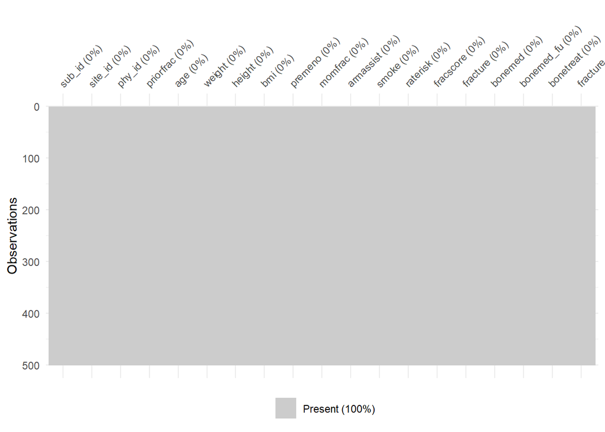

```r
vis_miss(mydata)
```

```r
dim(mydata)
```

```
## [1] 500  19
```

```r
#Factorize the categorized variables
library(dplyr)
mydata <- mydata%>% mutate_if(is.character, factor)
```

There are no missing values.